# OSU_Datafest_2023

Sitong Zhang(zhang.10730)

4/1/2023

```r
options(max.print = 10000)
```

# R Markdown

upload dataset

## Stats and Graph

```r
# Feature Engineering

# Replace 'NULL' with NA in 'Clients' dataframe
clients_na <- Clients %>%
  mutate(across(where(is.character), ~na_if(., 'NULL')))

# Create a dataframe with complete cases from 'clients_na'
clients_complete <- clients_na[complete.cases(clients_na),]

# Combine 'clients_na' with 'questions' to get the 'Category' variable
clients_category <- clients_na %>%
  left_join(Questions, by = c('ClientUno' = 'AskedByClientUno')) %>%
  select(Id.x, StateAbbr.x, ClientUno, County, EthnicIdentity, Age, Gender, MaritalStatus, Veteran, Imprisoned, NumberInHousehold, AnnualIncome, AllowedIncome, CheckingBalance, SavingsBalance, InvestmentsBalance, CreatedUtc, Category)
```

### Bar graph taken ratio of each category

```r
# Analyze which type of Questions is most frequent
# Count the number of each type of question
question_counts <- Questions %>%
  mutate(Taken = ifelse(TakenByAttorneyUno == 'NULL', 0, 1)) %>%
  group_by(Category, Taken) %>%
  summarize(n = n()) %>%
  arrange(desc(Taken))
```

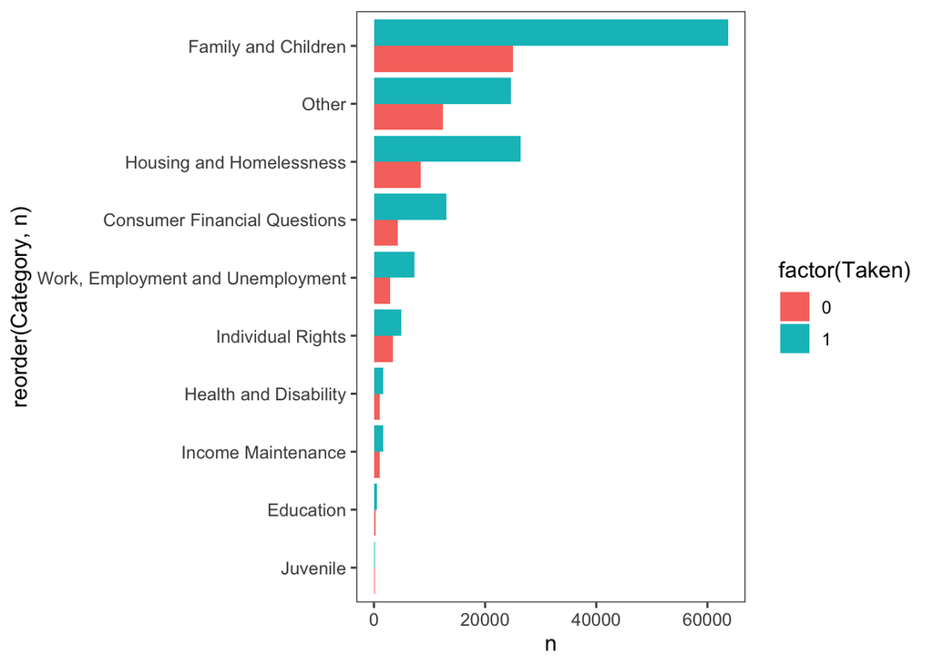

```r
# Plotting the count of Questions by category
Questions %>%
  mutate(Taken = ifelse(TakenByAttorneyUno == 'NULL', 0, 1)) %>%
  group_by(Category, Taken) %>%
  summarize(n = n()) %>%
  ggplot(mapping = aes(x = reorder(Category, n), y = n, fill = factor(Taken))) +
  geom_col(position = 'dodge') +
  coord_flip() +
  theme_few()
```

### Graph of Demand by State for Family and Children Category

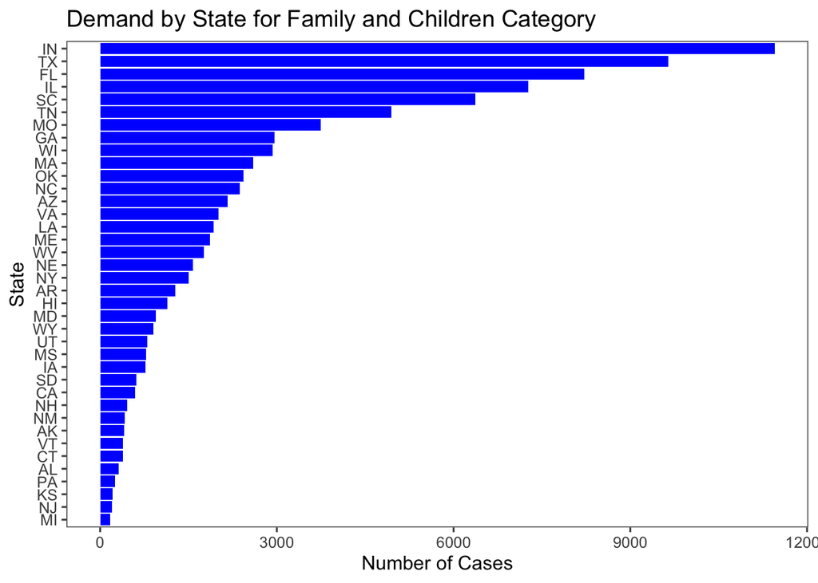

```r
# Analyzing 'Family and Children' Category
# Subset for 'Family and Children'
clients_cf <- clients_category %>%
  filter(Category == 'Family and Children')

# Analysis by State (Demand)
clients_cf_state_demand <- clients_cf %>%
  group_by(StateAbbr.x) %>%
  summarize(number = n())

# Plotting demand by state
ggplot(clients_cf_state_demand, aes(x = reorder(StateAbbr.x, number), y = number)) +
  geom_col(fill = 'blue') +
  coord_flip() +
  theme_few() +
  labs(title = "Demand by State for Family and Children Category", x = "State", y = "Number of Cases")
```

### Graph of Age Distribution in Family and Children Category

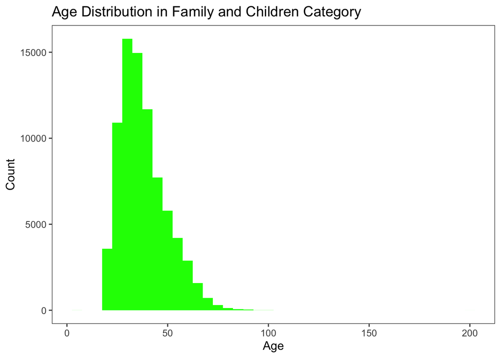

```r
# Analysis by Age
clients_cf_age_distribution <- clients_cf %>%
  mutate(age = as.numeric(Age))

# Plotting age distribution
ggplot(clients_cf_age_distribution, aes(x = age)) +
  geom_histogram(binwidth = 5, fill = 'green') +
  theme_few() +
  labs(title = "Age Distribution in Family and Children Category", x = "Age", y = "Count")
```

### Graph of Ethnic Distribution in Family and Children Category

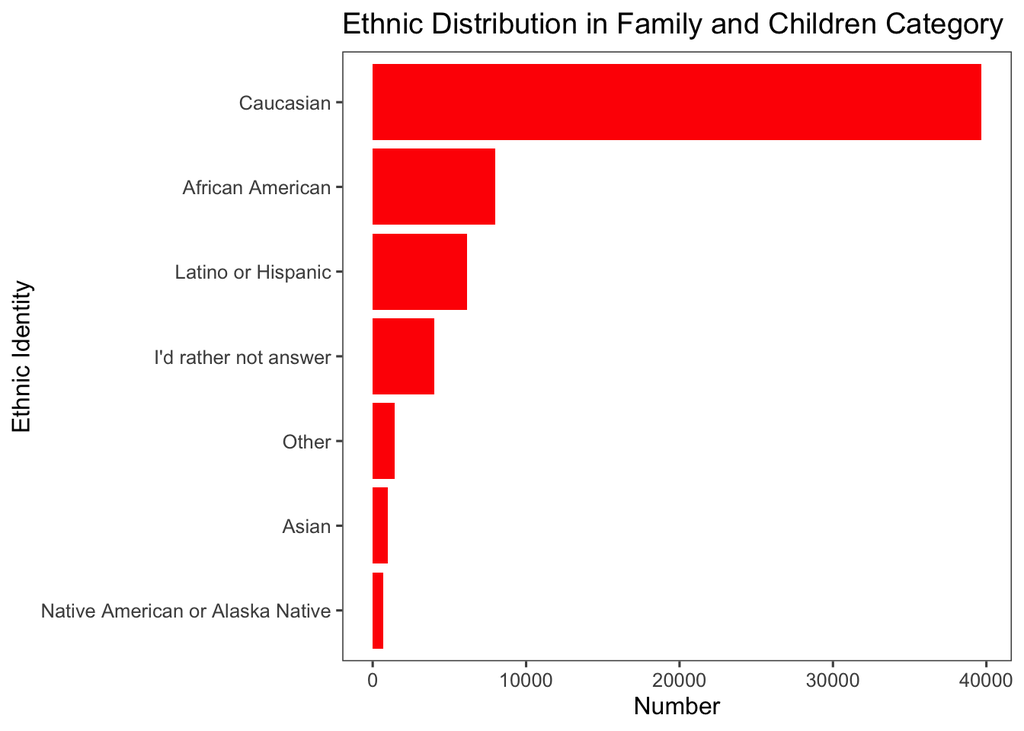

```r
# Analysis by Ethnic Identity
clients_cf_ethnic <- clients_cf %>%
  group_by(EthnicIdentity) %>%
  summarize(number = n()) %>%
  filter(number > mean(number)) %>%
  filter(EthnicIdentity %in% c('Caucasian', 'African American', 'Latino or Hispanic', "I'd rather not answer", 'Other', 'Asian', 'Native American or Alaska Native'))

# Plotting ethnic distribution
ggplot(clients_cf_ethnic, aes(x = reorder(EthnicIdentity, number), y = number)) +
  geom_col(fill = 'red') +
  coord_flip() +
  theme_few() +
  labs(title = "Ethnic Distribution in Family and Children Category", x = "Ethnic Identity", y = "Number")
```

### Pie graph of Subcategories

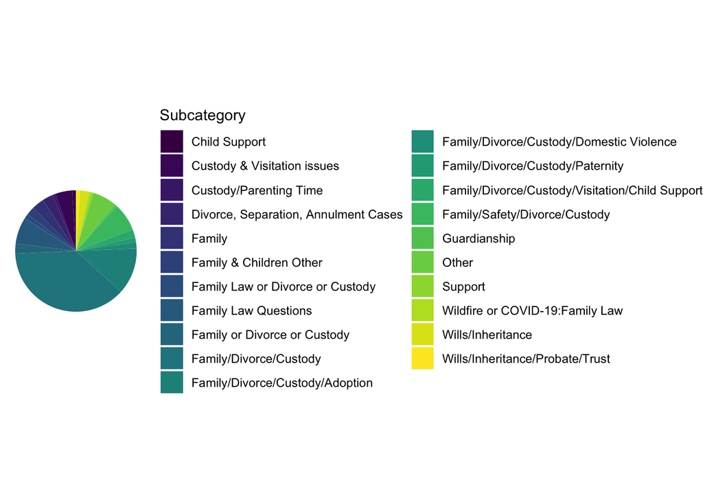

```r
# Feature Engineering for Subcategory
clients_subcategory <- clients_na %>%
  left_join(Questions, by = c('ClientUno' = 'AskedByClientUno')) %>%
  select(Id.x, StateAbbr.x, ClientUno, County, EthnicIdentity, Age, Gender, MaritalStatus, Veteran, Imprisoned, NumberInHousehold, AnnualIncome, AllowedIncome, CheckingBalance, SavingsBalance, InvestmentsBalance, CreatedUtc, Category, Subcategory)
# View(clients_subcategory)

# Filtering for 'Family and Children' Category
clients_cfsub <- clients_subcategory %>%
  filter(Category == 'Family and Children')
# View(clients_cfsub)

# Viewing levels of Subcategory within the 'Family and Children' Category
# levels(factor(clients_cfsub$Subcategory))

# Creating a Pie Chart for Subcategory Distribution
# Summarizing the count of each Subcategory
pietu <- clients_cfsub %>%
  group_by(Subcategory) %>%
  summarize(n = n())

# Define the number of top categories to display
top_n_categories <- 20

# Grouping all other categories under 'Other'
pietu_top <- pietu %>%
  arrange(desc(n)) %>%
  mutate(Subcategory = ifelse(row_number() > top_n_categories, 'Other', Subcategory)) %>%
  group_by(Subcategory) %>%
  summarize(n = sum(n))

# Creating the Pie Chart
ggplot(pietu_top, aes(x = "", y = n, fill = Subcategory)) +
  geom_bar(width = 1, stat = "identity") +
  coord_polar("y", start = 0) +
  theme_void() +
  theme(legend.position = "right") +
  guides(fill = guide_legend(title = "Subcategory")) +
  scale_fill_viridis_d()
```

## Q1 Study the relationship between legalDDL and if the case is taken

```r
# Reload Data sets for the following steps
Attorney <- read_csv("./data/data/attorneys.csv")
Attorney_time_entries <- read_csv("./data/data/attorneytimeentries.csv")
Categories <- read_csv("./data/data/categories.csv")
Clients <- read_csv("./data/data/clients.csv")
Question_posts <- read_csv("./data/data/questionposts.csv")
Questions <- read_csv("./data/data/questions.csv")
State_sites <- read_csv("./data/data/statesites.csv")
Subcategories <- read_csv("./data/data/subcategories.csv")
```

Detect if there is a huge difference the question will be taken when there is a legal deadline.

```r
# Create a new dataset based on the Questions data set
Question_for_if_legal_ddl_matter <- Questions

# Add the Indicator_if_Lddl variable
Question_for_if_legal_ddl_matter$Indicator_if_Lddl <- ifelse(Question_for_if_legal_ddl_matter$LegalDeadline == "NULL", 0, 1)

# Add the Indicator_if_taken variable
Question_for_if_legal_ddl_matter$Indicator_if_taken <- ifelse(Question_for_if_legal_ddl_matter$TakenByAttorneyUno == "NULL", 0, 1)

model <- glm(Indicator_if_taken ~ Indicator_if_Lddl, data=Question_for_if_legal_ddl_matter, family=binomial())
summary(model)
```

```
##
## Call:
## glm(formula = Indicator_if_taken ~ Indicator_if_Lddl, family = binomial(),
##     data = Question_for_if_legal_ddl_matter)
##
## Deviance Residuals:
##     Min       1Q   Median       3Q      Max
## -1.5759  -1.5628   0.8258   0.8258   0.8359
##
## Coefficients:
##                    Estimate Std. Error z value Pr(>|z|)
## (Intercept)        0.900742   0.005534 162.760   <2e-16 ***
## Indicator_if_Lddl -0.028920   0.011835  -2.444   0.0145 *
## ---
## Signif. codes:  0 '***' 0.001 '**' 0.01 '*' 0.05 '.' 0.1 ' ' 1
##
## (Dispersion parameter for binomial family taken to be 1)
##
##     Null deviance: 244398  on 202878  degrees of freedom
## Residual deviance: 244392  on 202877  degrees of freedom
## AIC: 244396
##
## Number of Fisher Scoring iterations: 4
```

```r
agg_data <- aggregate(Question_for_if_legal_ddl_matter$Indicator_if_taken,
                      by=list(Question_for_if_legal_ddl_matter$Indicator_if_Lddl),
                      FUN=mean)
names(agg_data) <- c("Indicator_if_Lddl", "Proportion_taken_by_attorney")
agg_data
```

```
##   Indicator_if_Lddl Proportion_taken_by_attorney
## 1                 0                    0.7111020
## 2                 1                    0.7051247
```

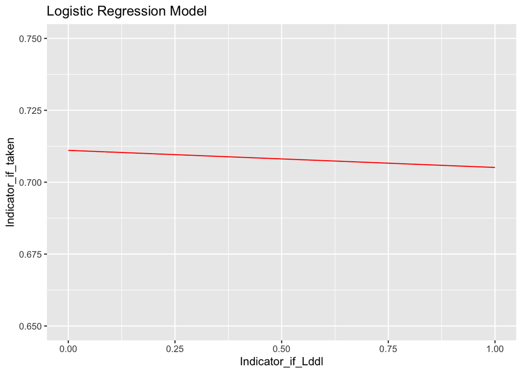

```r
# Create a dataframe with predicted values for the model
pred_df <- data.frame(Indicator_if_Lddl = c(0, 1))
pred_df$predicted_prob <- predict(model, newdata = pred_df, type = "response")

# Create the plot
ggplot(data = Question_for_if_legal_ddl_matter, aes(x = Indicator_if_Lddl, y = Indicator_if_taken)) +
  geom_point() +
  geom_line(data = pred_df, aes(x = Indicator_if_Lddl, y = predicted_prob), color = "red") +
  xlab("Indicator_if_Lddl") +
  ylab("Indicator_if_taken") +
  ggtitle("Logistic Regression Model") +
  ylim(0.65, 0.75)
```

The output from the logistic regression model provides information on the relationship between the Indicator_if_taken variable (i.e., whether or not a case was taken by an attorney) and the Indicator_if_Lddl variable (i.e., whether or not there is a legal deadline associated with the case).

The second part of the output provides information on the estimated coefficients for the model. The coefficient for the Indicator_if_Lddl variable is estimated to be -0.0289, with a standard error of 0.0118 and a z-value of -2.444. The negative sign of the coefficient indicates that the odds of a case being taken by an attorney decrease when there is a legal deadline associated with the case. The p-value associated with the coefficient is 0.0145, which is less than 0.05, indicating that the relationship between the Indicator_if_Lddl variable and the Indicator_if_taken variable is statistically significant.

The output also provides information on the null deviance, residual deviance, AIC, and number of iterations for the model. These values can be used to compare different models and evaluate their fit and complexity.

## Q2 Study the realtionship of the time attorney has joined ABA and number of cases taken

```r
# Aggregate the data by TakenByAttorneyUno and exclude rows with NULL
cases_by_agent <- Questions %>%
  filter(!is.null(TakenByAttorneyUno)) %>%
  group_by(TakenByAttorneyUno) %>%
  summarise(NumCases = n())
```

```r
# Aggregate the data by TakenByAttorneyUno and exclude rows with NULL
cases_by_attorney <- Questions %>%
  filter(!is.null(TakenByAttorneyUno)) %>%
  group_by(TakenByAttorneyUno) %>%
  summarise(NumCases = n())

# Full join the aggregated data with Attorney data frame on AttorneyUno
attorney_cases_and_join_date <- full_join(cases_by_attorney, Attorney, by = c("TakenByAttorneyUno" = "AttorneyUno"))

# Clean Data
attorney_cases_and_join_date <- subset(attorney_cases_and_join_date, TakenByAttorneyUno != "NULL")

# Replace NA values in NumCases with 0
attorney_cases_and_join_date$NumCases[is.na(attorney_cases_and_join_date$NumCases)] <- 0

# View the updated data frame
print(attorney_cases_and_join_date)
```

```
## # A tibble: 11,544 × 9
##    TakenByAttorneyUno         NumCa…¹    Id State…² City  County State…³ Posta…⁴
##    <chr>                        <dbl> <dbl> <chr>   <chr> <chr>  <chr>   <chr>
##  1 000B021F-9FBF-4058-8ADC-D…       1  4095 NY      Buff… Erie   New Yo… 14202
##  2 0023FF7C-934D-4974-87A9-B…       3 10656 TX      Hous… Harris Texas   77002
##  3 003C4876-C682-4E94-B161-4…       1  9420 IL      Chic… Cook   Illino… 60603
##  4 00401285-58EE-4E39-9807-8…       3  5443 TX      Moun… All N… Texas   22841
##  5 00609EE0-87BE-496A-9847-A…       7  3739 GA      ATLA… Clayt… Georgia 30315
##  6 00671667-CEAB-498B-B206-1…       4  9137 MA      Have… Essex  Massac… 01832
##  7 00714311-9110-4FC5-B306-6…      17  8950 NC      Rale… Wake   North … 27612
##  8 007C6655-D2ED-47D3-9FE4-2…      10   728 NH      Manc… Hills… New Ha… 03102
##  9 0088BE23-C57A-4EEE-8DDA-3…       6 10315 SC      Lexi… Lexin… South … 29072
## 10 008F43FB-682A-4663-845A-B…       5  3837 MO      St. … St. L… Missou… 63131
## # … with 11,534 more rows, 1 more variable: CreatedUtc <dttm>, and abbreviated
## #   variable names ¹NumCases, ²StateAbbr, ³StateName, ⁴PostalCode
```

```r
# Filter out rows with NULL in TakenByAttorneyUno
filtered_attorney_cases_and_join_date <- attorney_cases_and_join_date %>%
  filter(!is.null(TakenByAttorneyUno))

# Convert CreatedUtc to Date format (ignoring the time)
attorney_cases_and_join_date$CreatedUtc <- as.Date(attorney_cases_and_join_date$CreatedUtc)

# Define the max day
max_day <- as.Date("2022-01-24")

# Calculate the difference between the max day and each CreatedUtc value
attorney_cases_and_join_date$DaysSince_CreatedUtc_Day <- as.numeric(max_day - attorney_cases_and_join_date$CreatedUtc)

# Run linear regression using NumCases as the dependent variable and DaysSince_CreatedUtc_Day as the independent variable
regression_model <- lm(NumCases ~ DaysSince_CreatedUtc_Day, data = attorney_cases_and_join_date)

# Print the regression model summary
summary(regression_model)
```

```
##
## Call:
## lm(formula = NumCases ~ DaysSince_CreatedUtc_Day, data = attorney_cases_and_join_date)
##
## Residuals:
##    Min     1Q Median     3Q    Max
##  -36.1  -15.3   -8.9   -4.0 5100.8
##
## Coefficients:
##                          Estimate Std. Error t value Pr(>|t|)
## (Intercept)              1.623553   1.823035   0.891    0.373
## DaysSince_CreatedUtc_Day 0.008754   0.001242   7.048 1.92e-12 ***
## ---
## Signif. codes:  0 '***' 0.001 '**' 0.01 '*' 0.05 '.' 0.1 ' ' 1
##
## Residual standard error: 104.9 on 11542 degrees of freedom
## Multiple R-squared:  0.004285,   Adjusted R-squared:  0.004199
## F-statistic: 49.67 on 1 and 11542 DF,  p-value: 1.922e-12
```

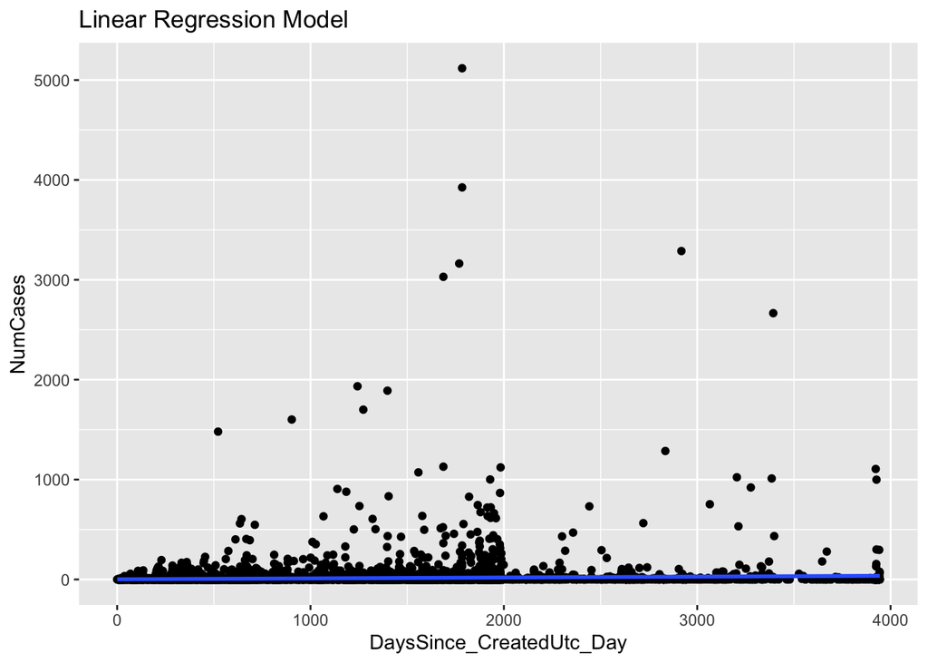

```r
# Create the plot-General
ggplot(data = attorney_cases_and_join_date, aes(x = DaysSince_CreatedUtc_Day, y = NumCases)) +
  geom_point() +
  geom_smooth(method = "lm", se = FALSE) +
  xlab("DaysSince_CreatedUtc_Day") +
  ylab("NumCases") +
  ggtitle("Linear Regression Model") +
  ylim(0, max(attorney_cases_and_join_date$NumCases, na.rm = TRUE))
```

```r
# Create the plot-Closer look(95%CI) Theoretical Function
# Fit linear regression model
regression_model <- lm(NumCases ~ DaysSince_CreatedUtc_Day, data = attorney_cases_and_join_date)

# Predict values for 95% interval
predictions <- predict(regression_model, interval = "confidence")

# Calculate y-axis limits
y_upper <- max(predictions[, "upr"], na.rm = TRUE)
y_lower <- min(predictions[, "lwr"], na.rm = TRUE)
c(y_lower ,y_upper)
```

```
## [1] -1.949904 43.006301
```

[figure not shown]

```r
# Create the plot
ggplot(data = attorney_cases_and_join_date, aes(x = DaysSince_CreatedUtc_Day, y = NumCases)) +
  geom_point(color = "steelblue", size = 0.5) +
  geom_smooth(method = "lm", se = FALSE, color = "darkred", linetype = "solid", size = 1.2) +
  geom_ribbon(aes(ymin = predictions[, "lwr"], ymax = predictions[, "upr"]),
              alpha = 0.2, fill = "lightblue") +
  scale_x_continuous("DaysSince_CreatedUtc_Day", expand = c(0, 0), breaks = seq(0, max(attorney_cases_and_join_date$DaysSince_CreatedUtc_Day), by = 10)) +
  scale_y_continuous("NumCases", limits = c(y_lower, y_upper), expand = c(0, 0), breaks = seq(y_lower, y_upper, by = 10)) +
  ggtitle("Linear Regression Model") +
  theme_minimal(base_size = 14) +
  theme(plot.title = element_text(size = 18, hjust = 0.5),
        axis.title.x = element_text(size = 16),
        axis.title.y = element_text(size = 16),
        panel.grid.minor = element_blank(),
        panel.grid.major = element_line(color = "grey92", size = 0.5))
```

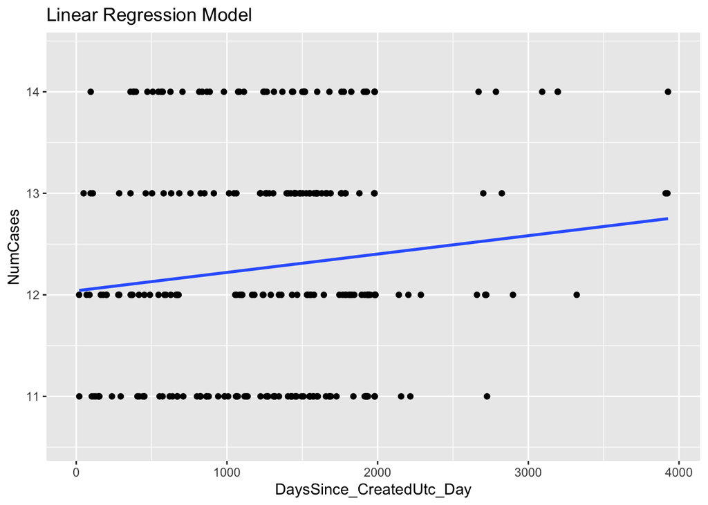

```r
# Create the plot-Closer look(95%CI) Sample Data
# Calculate 95% confidence interval for NumCases
confidence_interval <- t.test(attorney_cases_and_join_date$NumCases, conf.level = 0.95)$conf.int

# Create the plot
ggplot(data = attorney_cases_and_join_date, aes(x = DaysSince_CreatedUtc_Day, y = NumCases)) +
  geom_point() +
  geom_smooth(method = "lm", se = FALSE) +
  xlab("DaysSince_CreatedUtc_Day") +
  ylab("NumCases") +
  ggtitle("Linear Regression Model") +
  ylim(confidence_interval[1], confidence_interval[2])
```

```r
# mean join day
mean_join_day<- mean(attorney_cases_and_join_date$DaysSince_CreatedUtc_Day, na.rm = TRUE)
mean_join_year <- mean_join_day/365 ; mean_join_year
```

```
## [1] 3.395991
```

```r
average_taken_case <- 1.623553 + 0.008754 * mean_join_day; average_taken_case
```

```
## [1] 12.47446
```

### Q2 Advanced analysis of the ratio of the cases of each categories being taken

```r
# Calculate rate of cases being taken by Category
category_rate <- aggregate(Questions$TakenByAttorneyUno, by = list(Questions$Category), FUN = function(x) sum(x != "NULL")/length(x) * 100)

# Rename columns
names(category_rate) <- c("Category", "Rate")

# Print the result
category_rate
```

```
##                             Category     Rate
## 1       Consumer Financial Questions 75.28513
## 2                          Education 64.98741
## 3                Family and Children 71.75645
## 4              Health and Disability 62.83709
## 5           Housing and Homelessness 75.98907
## 6                 Income Maintenance 61.34673
## 7                  Individual Rights 59.70885
## 8                           Juvenile 57.42297
## 9                              Other 66.38329
## 10 Work, Employment and Unemployment 71.40473
```

Calculate the taken rate of each category and total taken rate expressed as a percentage:

```r
# Calculate taken rate by category
taken_rate_by_category <- Question_for_if_legal_ddl_matter %>%
  group_by(Category) %>%
  summarize(TotalCases = n(),
            TakenCases = sum(Indicator_if_taken),
            TakenRate = (TakenCases / TotalCases) * 100)

# Calculate the overall taken rate
overall_taken_rate <- Question_for_if_legal_ddl_matter %>%
  summarize(TotalCases = n(),
            TakenCases = sum(Indicator_if_taken),
            TakenRate = (TakenCases / TotalCases) * 100) %>%
  mutate(Category = "Total")

# Combine the overall taken rate with the taken rate by category
combined_result <- rbind(taken_rate_by_category, overall_taken_rate)

# Print the combined result
print(combined_result)
```

```
## # A tibble: 11 × 4
##    Category                          TotalCases TakenCases TakenRate
##    <chr>                                  <int>      <dbl>     <dbl>
##  1 Consumer Financial Questions           17273      13004      75.3
##  2 Education                                794        516      65.0
##  3 Family and Children                    88753      63686      71.8
##  4 Health and Disability                   2707       1701      62.8
##  5 Housing and Homelessness               34755      26410      76.0
##  6 Income Maintenance                      2688       1649      61.3
##  7 Individual Rights                       8312       4963      59.7
##  8 Juvenile                                 357        205      57.4
##  9 Other                                  37053      24597      66.4
## 10 Work, Employment and Unemployment      10187       7274      71.4
## 11 Total                                 202879     144005      71.0
```

```r
# Perform Chi-Square to see if means are different between categories

# Create a contingency table of Category and Indicator_if_taken
contingency_table <- table(Question_for_if_legal_ddl_matter$Category, Question_for_if_legal_ddl_matter$Indicator_if_taken)

# Perform the Chi-square test
chi_square_test <- chisq.test(contingency_table)

# Print the result
print(chi_square_test)
```

```
##
##  Pearson's Chi-squared test
##
## data:  contingency_table
## X-squared = 1752.3, df = 9, p-value < 2.2e-16
```

The output you provided shows the results of the Pearson’s Chi-squared test on the contingency table of Category and Indicator_if_taken. Here’s how to interpret the results:

X-squared: The Chi-square statistic value is 1752.3. This value is used to determine the significance of the test. df: Degrees of freedom for this test is 9. It is calculated as (number of categories - 1) x (number of levels of Indicator_if_taken - 1) = (10 - 1) x (2 - 1) = 9. p-value: The p-value is less than 2.2e-16, which is extremely small and much lower than the common significance level of 0.05. Since the p-value is less than 0.05, you can reject the null hypothesis and conclude that there is a statistically significant difference in the taken rates between the categories.

## Combining 1 and 2, I want to explore whether categories with a Taken rate less than 60 and 75 are influenced by the existence of a legal ddl (whether a legal ddl is an essential element for the Taken rate).

### Combining 1 and 2, I want to explore whether categories with a Taken rate less than 60 are influenced by the existence of a legal ddl (whether a legal ddl is an essential element for the Taken rate).

```r
# Filter the categories with a taken rate below 60%
categories_below_60 <- taken_rate_by_category %>%
  filter(TakenRate < 60) %>%
  pull(Category)

# Filter the dataset to only include categories with a taken rate smaller than 60%
filtered_data <- Question_for_if_legal_ddl_matter %>%
  filter(Category %in% categories_below_60)

# Fit logistic regression model with interaction term
logit_model_interaction <- glm(Indicator_if_taken ~ Category * Indicator_if_Lddl,
                               data = filtered_data,
                               family = binomial(link = "logit"))

# Display the model summary for the model with interaction term
summary(logit_model_interaction)
```

```
##
## Call:
## glm(formula = Indicator_if_taken ~ Category * Indicator_if_Lddl,
##     family = binomial(link = "logit"), data = filtered_data)
##
## Deviance Residuals:
##    Min      1Q  Median      3Q     Max
## -1.367  -1.356   1.009   1.009   1.194
##
## Coefficients:
##                                    Estimate Std. Error z value Pr(>|z|)
## (Intercept)                         0.41001    0.02585  15.862   <2e-16 ***
## CategoryJuvenile                    0.02473    0.13030   0.190   0.8495
## Indicator_if_Lddl                  -0.06657    0.05156  -1.291   0.1966
## CategoryJuvenile:Indicator_if_Lddl -0.40817    0.24287  -1.681   0.0928 .
## ---
## Signif. codes:  0 '***' 0.001 '**' 0.01 '*' 0.05 '.' 0.1 ' ' 1
##
## (Dispersion parameter for binomial family taken to be 1)
##
##     Null deviance: 11695  on 8668  degrees of freedom
## Residual deviance: 11689  on 8665  degrees of freedom
## AIC: 11697
##
## Number of Fisher Scoring iterations: 4
```

```r
# Perform logistic regression without interaction term
logit_model_no_interaction <- glm(Indicator_if_taken ~ Category,
                                  data = filtered_data,
                                  family = binomial(link = "logit"))

# Display the model summary for the model without interaction term
summary(logit_model_no_interaction)
```

```
##
## Call:
## glm(formula = Indicator_if_taken ~ Category, family = binomial(link = "logit"),
##     data = filtered_data)
##
## Deviance Residuals:
##    Min      1Q  Median      3Q     Max
## -1.348  -1.348   1.016   1.016   1.053
##
## Coefficients:
##                  Estimate Std. Error z value Pr(>|z|)
## (Intercept)       0.39335    0.02236  17.590   <2e-16 ***
## CategoryJuvenile -0.09422    0.10935  -0.862    0.389
## ---
## Signif. codes:  0 '***' 0.001 '**' 0.01 '*' 0.05 '.' 0.1 ' ' 1
##
## (Dispersion parameter for binomial family taken to be 1)
##
##     Null deviance: 11695  on 8668  degrees of freedom
## Residual deviance: 11694  on 8667  degrees of freedom
## AIC: 11698
##
## Number of Fisher Scoring iterations: 4
```

### Combining 1 and 2, I want to explore whether categories with a Taken rate greater than 75 are influenced by the existence of a legal ddl (whether a legal ddl is an essential element for the Taken rate).

```r
# Filter the categories with a taken rate above 75%
categories_above_75 <- taken_rate_by_category %>%
  filter(TakenRate > 75) %>%
  pull(Category)

categories_above_75
```

```
## [1] "Consumer Financial Questions" "Housing and Homelessness"
```

```r
# Filter the dataset to only include categories with a taken rate greater than 75%
filtered_data <- Question_for_if_legal_ddl_matter %>%
  filter(Category %in% categories_above_75)

# Fit logistic regression model with interaction term
logit_model_interaction <- glm(Indicator_if_taken ~ Category * Indicator_if_Lddl,
                               data = filtered_data,
                               family = binomial(link = "logit"))

# Display the model summary for the model with interaction term
summary(logit_model_interaction)
```

```
##
## Call:
## glm(formula = Indicator_if_taken ~ Category * Indicator_if_Lddl,
##     family = binomial(link = "logit"), data = filtered_data)
##
## Deviance Residuals:
##     Min       1Q   Median       3Q      Max
## -1.7515   0.6971   0.7319   0.7720   0.7733
##
## Coefficients:
##                                                    Estimate Std. Error z value
## (Intercept)                                         1.05411    0.02026  52.027
## CategoryHousing and Homelessness                    0.12624    0.02484   5.081
## Indicator_if_Lddl                                   0.23683    0.04131   5.733
## CategoryHousing and Homelessness:Indicator_if_Lddl -0.35914    0.05079  -7.071
##                                                    Pr(>|z|)
## (Intercept)                                         < 2e-16 ***
## CategoryHousing and Homelessness                   3.74e-07 ***
## Indicator_if_Lddl                                  9.84e-09 ***
## CategoryHousing and Homelessness:Indicator_if_Lddl 1.54e-12 ***
## ---
## Signif. codes:  0 '***' 0.001 '**' 0.01 '*' 0.05 '.' 0.1 ' ' 1
##
## (Dispersion parameter for binomial family taken to be 1)
##
##     Null deviance: 57635  on 52027  degrees of freedom
## Residual deviance: 57581  on 52024  degrees of freedom
## AIC: 57589
##
## Number of Fisher Scoring iterations: 4
```

```r
# Perform logistic regression without interaction term
logit_model_no_interaction <- glm(Indicator_if_taken ~ Category,
                                  data = filtered_data,
                                  family = binomial(link = "logit"))

# Display the model summary for the model without interaction term
summary(logit_model_no_interaction)
```

```
##
## Call:
## glm(formula = Indicator_if_taken ~ Category, family = binomial(link = "logit"),
##     data = filtered_data)
##
## Deviance Residuals:
##     Min       1Q   Median       3Q      Max
## -1.6892   0.7410   0.7410   0.7410   0.7535
##
## Coefficients:
##                                  Estimate Std. Error z value Pr(>|z|)
## (Intercept)                       1.11388    0.01764  63.147   <2e-16 ***
## CategoryHousing and Homelessness  0.03820    0.02165   1.764   0.0777 .
## ---
## Signif. codes:  0 '***' 0.001 '**' 0.01 '*' 0.05 '.' 0.1 ' ' 1
##
## (Dispersion parameter for binomial family taken to be 1)
##
##     Null deviance: 57635  on 52027  degrees of freedom
## Residual deviance: 57632  on 52026  degrees of freedom
## AIC: 57636
##
## Number of Fisher Scoring iterations: 4
```

Interpreting the coefficient in with interaction model will give us “Consumer Financial Questions” is exp{1.05411}, “Housing and Homelessness” exp{1.05411+0.12624}. It tells us that “Consumer Financial Question” that has no legal ddl has statistically significant difference with “Housing and Homelessness”, “Consumer Financial Question” that has legal ddl, and “Housing and Homelessness” with legal ddl.

Interpreting the coefficient in no interaction model just give us the overall taken rate of “Consumer Financial Questions” and “Housing and Homelessness”. And only intercept is statistically significant.

## Anlysis for Family and Children category only

```r
# Filter the dataset to only include the "Family and Children" category
filtered_data <- Question_for_if_legal_ddl_matter %>%
  filter(Category == "Family and Children")

# Perform logistic regression with Indicator_if_Lddl as the only predictor
logit_model_FAC <- glm(Indicator_if_taken ~ Indicator_if_Lddl,
                   data = filtered_data,
                   family = binomial(link = "logit"))

# Display the model summary
summary(logit_model_FAC)
```

```
##
## Call:
## glm(formula = Indicator_if_taken ~ Indicator_if_Lddl, family = binomial(link = "logit"),
##     data = filtered_data)
##
## Deviance Residuals:
##     Min       1Q   Median       3Q      Max
## -1.5999  -1.5875   0.8168   0.8168   0.8168
##
## Coefficients:
##                   Estimate Std. Error z value Pr(>|z|)
## (Intercept)        0.92644    0.00842 110.033   <2e-16 ***
## Indicator_if_Lddl  0.02757    0.01813   1.521    0.128
## ---
## Signif. codes:  0 '***' 0.001 '**' 0.01 '*' 0.05 '.' 0.1 ' ' 1
##
## (Dispersion parameter for binomial family taken to be 1)
##
##     Null deviance: 105658  on 88752  degrees of freedom
## Residual deviance: 105656  on 88751  degrees of freedom
## AIC: 105660
##
## Number of Fisher Scoring iterations: 4
```

There is no statistically significant within Family and Children between the No_Legal_ddl group and With_Legal_ddl group.

### TS Family and Children

Categorizing Family and Children, Indicator_if_taken = 0 and Indicator_if_taken = 1.

```r
# Filter the dataset for the "Family and Children" category and Indicator_if_taken
family_children_data_taken <- Question_for_if_legal_ddl_matter %>%
  filter(Category == "Family and Children" & Indicator_if_taken == 1)

family_children_data_not_taken <- Question_for_if_legal_ddl_matter %>%
  filter(Category == "Family and Children" & Indicator_if_taken == 0)


family_children_monthly_taken <- family_children_data_taken %>%
  mutate(Month = floor_date(AskedOnUtc, "month")) %>%
  group_by(Month) %>%
  summarize(NumQuestions = n()) %>%
  ungroup()

family_children_monthly_not_taken <- family_children_data_not_taken %>%
  mutate(Month = floor_date(AskedOnUtc, "month")) %>%
  group_by(Month) %>%
  summarize(NumQuestions = n()) %>%
  ungroup()


family_children_ts_taken <- ts(family_children_monthly_taken$NumQuestions,
                               start = c(year(min(family_children_monthly_taken$Month)), month(min(family_children_monthly_taken$Month))),
                               frequency = 12)

family_children_ts_not_taken <- ts(family_children_monthly_not_taken$NumQuestions,
                                   start = c(year(min(family_children_monthly_not_taken$Month)), month(min(family_children_monthly_not_taken$Month))),
                                   frequency = 12)

model_taken <- auto.arima(family_children_ts_taken)
summary(model_taken)
```

```
## Series: family_children_ts_taken
## ARIMA(1,1,0)(0,0,1)[12]
##
## Coefficients:
##           ar1    sma1
##       -0.3218  0.4032
## s.e.   0.1044  0.1373
##
## sigma^2 = 8966:  log likelihood = -662.73
## AIC=1331.45   AICc=1331.68   BIC=1339.58
##
## Training set error measures:
##                    ME     RMSE     MAE        MPE     MAPE      MASE
## Training set 3.602473 93.41101 61.7891 -0.9908361 20.56277 0.3131733
##                     ACF1
## Training set -0.01686426
```

```r
model_not_taken <- auto.arima(family_children_ts_not_taken)
summary(model_not_taken)
```

```
## Series: family_children_ts_not_taken
## ARIMA(1,1,0)(1,0,0)[12]
##
## Coefficients:
##           ar1    sar1
##       -0.1943  0.4227
## s.e.   0.0971  0.0912
##
## sigma^2 = 3006:  log likelihood = -591.31
## AIC=1188.61   AICc=1188.84   BIC=1196.69
##
## Training set error measures:
##                    ME     RMSE      MAE       MPE     MAPE      MASE
## Training set 4.609225 54.07166 37.66006 -1.930039 20.92143 0.3612652
##                      ACF1
## Training set -0.005585016
```

Combining the two sets of data mentioned above, continue with time series modeling.

```r
# Combine the taken and not taken time series
family_children_ts_combined <- family_children_ts_taken + family_children_ts_not_taken

# Fit a combined time series model
combined_model <- auto.arima(family_children_ts_combined, seasonal = TRUE, stepwise = FALSE, approximation = FALSE)

# Display the model summary
summary(combined_model)
```

```
## Series: family_children_ts_combined
## ARIMA(1,1,0)(1,0,0)[12]
##
## Coefficients:
##           ar1    sar1
##       -0.2702  0.4311
## s.e.   0.0975  0.0883
##
## sigma^2 = 13428:  log likelihood = -672.96
## AIC=1351.91   AICc=1352.14   BIC=1359.99
##
## Training set error measures:
##                   ME     RMSE     MAE      MPE     MAPE      MASE        ACF1
## Training set 5.85137 114.2898 73.4504 1.310721 11.41816 0.3081791 -0.01859332
```

Since it is ar1 and sar1, it has trend and seasonality. It is influenced by the immediate past value and the value 12 months ago(n=12). Since it is ARIMA(1,1,0)(1,0,0)[12], in the non seasonal part, it shows differencing is 1, there is a trend. Meanwhile, in the seasonal part, it shows differencing is 0, so the trend is seasonally contant throughout years.

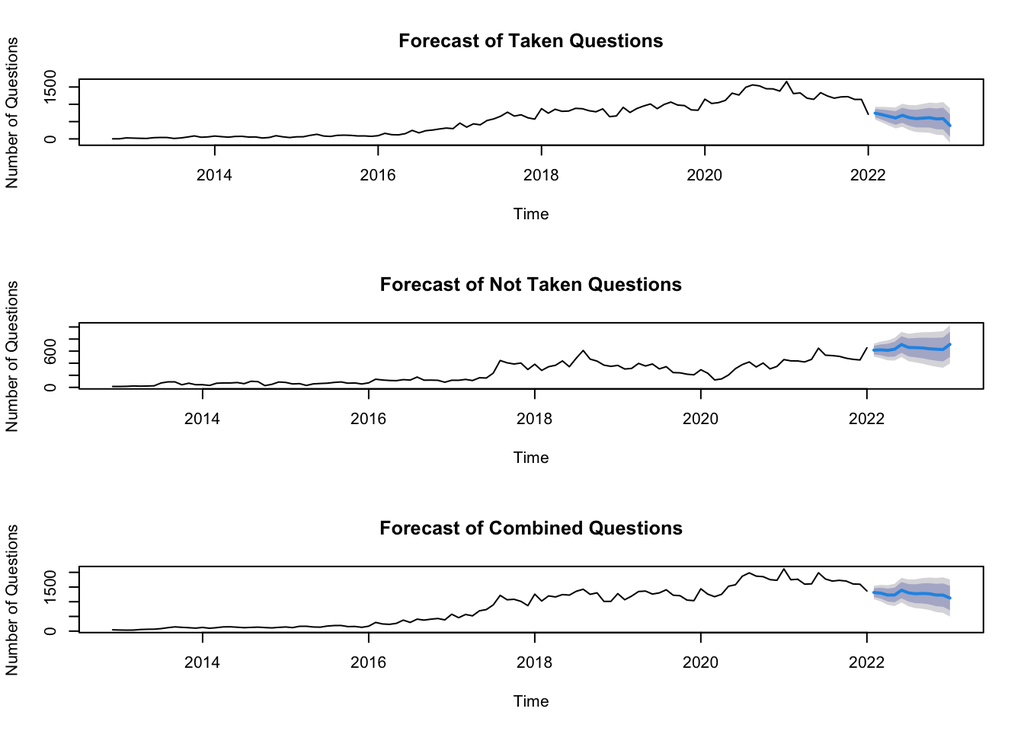

```r
# Number of periods to forecast
n_periods <- 12

# Forecast taken questions
forecast_taken <- forecast(model_taken, h = n_periods)
# Forecast not taken questions
forecast_not_taken <- forecast(model_not_taken, h = n_periods)
# Forecast combined questions
forecast_combined <- forecast(combined_model, h = n_periods)


# Create the plots
par(mfrow = c(3, 1))

# Plot taken questions
plot(forecast_taken, main = "Forecast of Taken Questions", ylab = "Number of Questions", xlab = "Time")
# Plot not taken questions
plot(forecast_not_taken, main = "Forecast of Not Taken Questions", ylab = "Number of Questions", xlab = "Time")
# Plot combined questions
plot(forecast_combined, main = "Forecast of Combined Questions", ylab = "Number of Questions", xlab = "Time")
```

```r
# Reset the plotting parameters
par(mfrow = c(1, 1))
```